# MHDPRSSN preprocessing

Chi-Lam Poon

MHDPRSSN means the medical history of depression – A mood disorder having a clinical course involving one or more episodes of serious psychological depression that last two or more weeks each, do not have intervening episodes of mania or hypomania, and are characterized by a loss of interest or pleasure in almost all activities and by some or all of disturbances of appetite, sleep, or psychomotor functioning, a decrease in energy, difficulties in thinking or making decisions, loss of self-esteem or feelings of guilt, and suicidal thoughts or attempts. (from [here](https://www.ncbi.nlm.nih.gov/projects/gap/cgi-bin/variable.cgi?study_id=phs000424.v8.p2&phv=169145&phd=3910&pha=&pht=2742&phvf=&phdf=&phaf=&phtf=&dssp=1&consent=&temp=1))

Similar to MHCVD processing.

Filter genes in a *tissue-aware* manner. Details see the YARN paper.

```r
suppressPackageStartupMessages({
  library(yarn)
  library(stringr)
  library(Biobase)
  library(dplyr)
  library(rafalib)
  library(readr)
  library(ggplot2)
  library(ggpubr)
  library(edgeR)
})
```

## Load data

```r
eset <- readRDS("~/cvd/v8/exprs/gtex.v8.rds")
dim(eset)
```

```
## Features  Samples
##    56200    17382
```

## Modify and filter subjects

Criteria:

1. MHDPRSSN was recorded as value `0 (No)`, `1 (Yes)` and `99 (Unknown)`, therefore subjects with `0` or `1` were kept
2. Remove samples with `NA` Hardy scale values
3. Remove samples with `NA` ischemic time
4. Remove samples without batch info.

```r
# filter according to the criteria
sub.eset <- eset[, which((pData(eset)$MHDPRSSN %in% c(0, 1)) &
                           (!is.na(pData(eset)$DTHHRDY)) &
                           (!is.na(pData(eset)$SMTSISCH)) &
                           (pData(eset)$SMNABTCHT != ""))]

dim(sub.eset); length(unique(pData(sub.eset)$SUBJID)); all(rownames(pData(sub.eset)) == colnames(exprs(sub.eset)))
```

```
## Features  Samples
##    56200    17138
```

```
## [1] 926
```

```
## [1] TRUE
```

## Remove unwanted tissues

Let’s see how many samples first.

```r
pdata <- pData(sub.eset)
pdata$MHDPRSSN <- factor(pdata$MHDPRSSN)

m_count1 <- pdata %>% group_by(MHDPRSSN) %>% summarise(counts = n())
m_count2 <- pdata %>% group_by(SMTSD, MHDPRSSN) %>% summarise(counts = n())
```

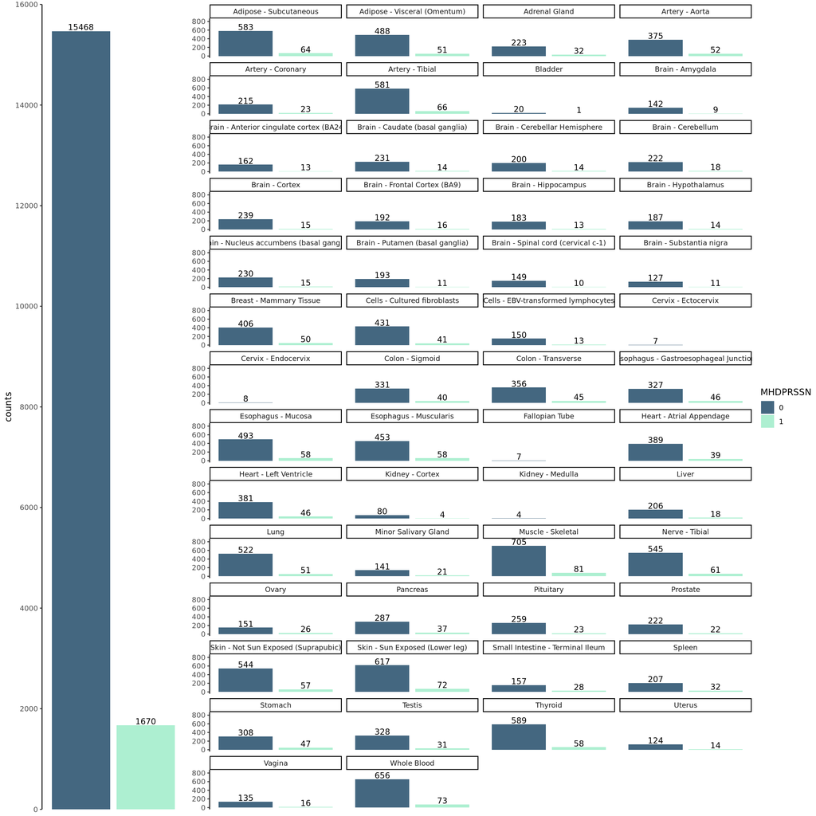

```r
# replace long names
# m_count2$our_subtypes <- gsub('adipose visceral \\(omentum\\)', 'adipose visceral', m_count2$our_subtypes)
# m_count2$our_subtypes <- gsub('esophagus gastroesophageal junction', 'gastroesophageal junction', m_count2$our_subtypes)
# m_count2$our_subtypes <- gsub('small intestine terminal ileum', 'intestine terminal ileum', m_count2$our_subtypes)

m1 <- ggplot(m_count1, aes(x=MHDPRSSN, y=counts, fill=MHDPRSSN)) +
  geom_bar(stat = "identity") +
  geom_text(aes(label=counts), vjust = -0.17, size = 3.5) +
  theme_classic() + theme(axis.title.x=element_blank()) +
  scale_fill_manual(values = c("#446780", "#ADEFD1FF")) +
  theme(axis.title.x=element_blank(),
        axis.text.x=element_blank(),
        axis.line.x=element_blank(),
        axis.ticks.x=element_blank()) +
  scale_y_continuous(limits=c(0,16000), breaks=seq(0,16000,by=2000), expand=c(0,0))

m2 <- ggplot(m_count2, aes(x=MHDPRSSN, y=counts, fill=MHDPRSSN)) +
  geom_bar(stat="identity") +
  geom_text(aes(label=counts), vjust = -0.14, size = 3.5) +
  theme_classic() +
  theme(axis.title.x=element_blank(),
        axis.text.x=element_blank(),
        axis.title.y=element_blank(),
        axis.line.x=element_blank(),
        axis.ticks.x=element_blank()) +
  scale_fill_manual(values = c("#446780", "#ADEFD1FF")) +
  scale_y_continuous(limits=c(0,830)) +
  facet_wrap(~SMTSD, ncol=4)

ggarrange(m1, m2, ncol=2, nrow=1, widths=c(1,3), common.legend = T, legend = "right")
```

Exclude following tissues based on sample number (`MHDPRSSN=1` >= 10). Check GTEx [tissue sampling sites](https://gtexportal.org/home/samplingSitePage)

- Cells - Cultured fibroblasts
- Cells - EBV-transformed lymphocytes
- Cells - Leukemia cell line (CML)
- Bladder
- Brain - Amygdala
- Cervix - Ectocervix
- Cervix - Endocervix
- Fallopian Tube
- Kidney - Cortex
- Kidney - Medulla

```r
dim(sub.eset)
```

```
## Features  Samples
##    56200    17138
```

```r
throwTissues <- c('Cells - Cultured fibroblasts', 'Cells - EBV-transformed lymphocytes', 'Cells - Leukemia cell line (CML)', 'Cervix - Ectocervix', 'Cervix - Endocervix', 'Bladder', 'Fallopian Tube', 'Kidney - Cortex', 'Kidney - Medulla', 'Brain - Amygdala')

sub.eset2 <- sub.eset[, which(!pData(sub.eset)$SMTSD %in% throwTissues)]
dim(sub.eset2); all(rownames(pData(sub.eset2))==colnames(exprs(sub.eset2)))
```

```
## Features  Samples
##    56200    16221
```

```
## [1] TRUE
```

## View the samples again

MHDPRSSN in v8!

```r
table(pData(sub.eset2)$MHDPRSSN)
```

```
##
##     0     1
## 14619  1602
```

```r
pData(sub.eset2)$MHDPRSSN <- factor(pData(sub.eset2)$MHDPRSSN)

m_count1 <- pData(sub.eset2) %>% group_by(MHDPRSSN) %>% summarise(counts = n())
m_count2 <- pData(sub.eset2) %>% group_by(SMTSD, MHDPRSSN) %>% summarise(counts = n())
```

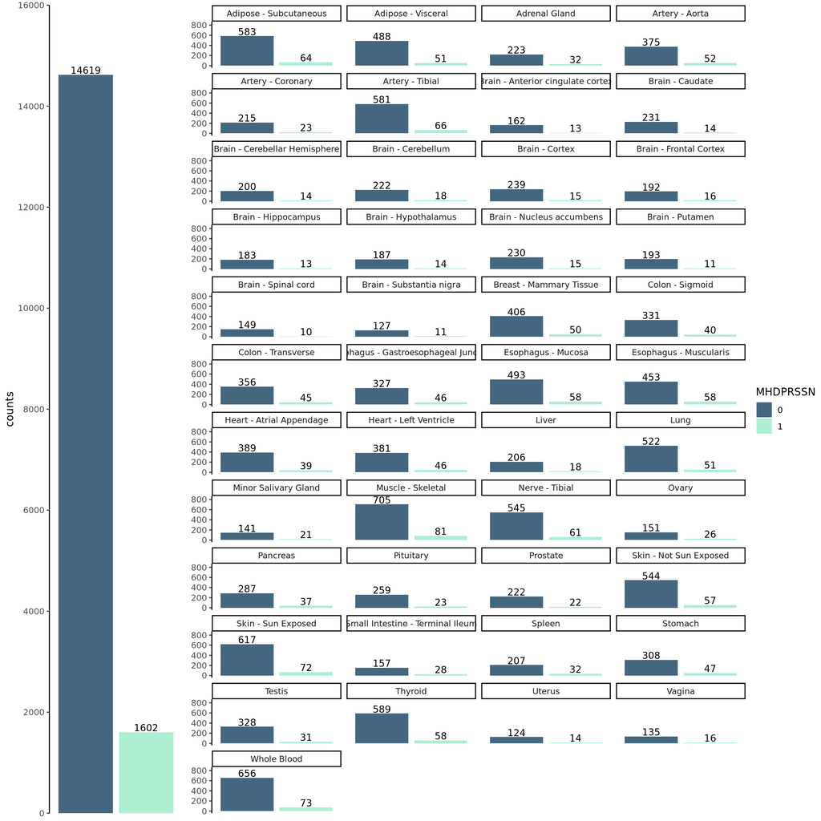

```r
# remove parentheses and contents within
m_count2$SMTSD <- gsub("\\s*\\([^\\)]+\\)", "", as.character(m_count2$SMTSD))

m1 <- ggplot(m_count1, aes(x=MHDPRSSN, y=counts, fill=MHDPRSSN)) +
  geom_bar(stat = "identity") +
  geom_text(aes(label=counts), vjust = -0.17, size = 3.5) +
  theme_classic() + theme(axis.title.x=element_blank()) +
  scale_fill_manual(values = c("#446780", "#ADEFD1FF")) +
  theme(axis.title.x=element_blank(),
        axis.text.x=element_blank(),
        axis.line.x=element_blank(),
        axis.ticks.x=element_blank()) +
  scale_y_continuous(limits=c(0,16000), breaks=seq(0,16000,by=2000), expand=c(0,0))

m2 <- ggplot(m_count2, aes(x=MHDPRSSN, y=counts, fill=MHDPRSSN)) +
  geom_bar(stat="identity") +
  geom_text(aes(label=counts), vjust = -0.14, size = 3.5) +
  theme_classic() +
  theme(axis.title.x=element_blank(),
        axis.text.x=element_blank(),
        axis.title.y=element_blank(),
        axis.line.x=element_blank(),
        axis.ticks.x=element_blank()) +
  scale_fill_manual(values = c("#446780", "#ADEFD1FF")) +
  scale_y_continuous(limits=c(0,830)) +
  facet_wrap(~SMTSD, ncol=4)

ggarrange(m1, m2, ncol=2, nrow=1, widths=c(1,3), common.legend = T, legend = "right")
```

## Filter genes

Need to filter out some lowly-expressed genes.

### Remove those were 0 across all samples

```r
for (i in 1:nrow(problems(exprs(sub.eset2)))) {
  exprs(sub.eset2)[problems(exprs(sub.eset2))$row[i], problems(exprs(sub.eset2))$col[i]] <- 1e+05
}
throwAway <- which(rowSums(exprs(sub.eset2)) == 0) # 326
sub.eset3 <- sub.eset2[-throwAway, ]
rm(sub.eset, sub.eset2)
```

### Detele Y genes

```r
sub.eset4 <- sub.eset3[which(fData(sub.eset3)$chr != 'Y'),] # 500 genes
```

### Filter genes in a tissue-aware manner

Genes < 1 CPM in fewer than half of the number of samples of the smallest set of related samples are **out**.

```r
pData(sub.eset4)$SMTSD <- factor(pData(sub.eset4)$SMTSD)
minSamples <- min(table(pData(sub.eset4)$SMTSD))
minSamples <- floor(minSamples / 2)
counts <- cpm(exprs(sub.eset4))
keep <- rowSums(counts > 1) >= minSamples
sum(keep)
```

```
## [1] 29063
```

```r
sub.eset5 <- sub.eset4[keep,]
dim(sub.eset5)
```

```
## Features  Samples
##    29063    16221
```

```r
rm(sub.eset3, sub.eset4)
```

## Tissue-aware quantile normalization

```r
source('~/cvd/v8/scripts/tissueAwareNorm.R')
normalizedMatrix <- tissue.aware.norm(sub.eset5, "SMTSD", 'QN')
all(colnames(normalizedMatrix)==rownames(pData(sub.eset5)))
```

```
## [1] TRUE
```

```r
storageMode(sub.eset5) <- "environment"
assayData(sub.eset5)[["normalizedMatrix"]] <- normalizedMatrix
storageMode(sub.eset5) <- "lockedEnvironment"
```

## Save data

```r
saveRDS(sub.eset5, file='~/cvd/v8/exprs/gtex.mdd.filted.norm.rds')
```